# Regression Models Project

Hailu Teju

October 8, 2017

## Motor Trend: Automatics vs manual transmission cars

You work for Motor Trend, a magazine about the automobile industry. Looking at a data set of a collection of cars, they are interested in exploring the relationship between a set of variables and miles per gallon (MPG) (outcome). They are particularly interested in the following two questions:

- “Is an automatic or manual transmission better for MPG”
- “Quantify the MPG difference between automatic and manual transmissions”

### Getting Data

```
## 'data.frame':    32 obs. of  11 variables:
##  $ mpg : num  21 21 22.8 21.4 18.7 18.1 14.3 24.4 22.8 19.2 ...
##  $ cyl : num  6 6 4 6 8 6 8 4 4 6 ...
##  $ disp: num  160 160 108 258 360 ...
##  $ hp  : num  110 110 93 110 175 105 245 62 95 123 ...
##  $ drat: num  3.9 3.9 3.85 3.08 3.15 2.76 3.21 3.69 3.92 3.92 ...
##  $ wt  : num  2.62 2.88 2.32 3.21 3.44 ...
##  $ qsec: num  16.5 17 18.6 19.4 17 ...
##  $ vs  : num  0 0 1 1 0 1 0 1 1 1 ...
##  $ am  : num  1 1 1 0 0 0 0 0 0 0 ...
##  $ gear: num  4 4 4 3 3 3 3 4 4 4 ...
##  $ carb: num  4 4 1 1 2 1 4 2 2 4 ...
```

### Overview

As we can see, the $\verb+mtcars+$ data set has 11 variables and 32 observations. Here, we would like to analyze the relationship between mpg and the other variables. Let’s start by checking the correlation between mpg and the other variables using R’s cor() function.

```
##            cyl       disp         hp      drat         wt     qsec
## [1,] -0.852162 -0.8475514 -0.7761684 0.6811719 -0.8676594 0.418684
##             vs        am      gear       carb
## [1,] 0.6640389 0.5998324 0.4802848 -0.5509251
```

The correlation result shows that miles per gallon (mpg) is negatively correlated with number of cylinders (cyl), displacement (disp), horse power (hp), weight (wt), and number of carburetors (carb).

### Automatic vs manual transmissions

The codebook for mtcars (?mtcars) indicates that the transmission types (am) are identified as:

- 0 = automatic
- 1 = manual

```
## [1] Manual    Manual    Manual    Automatic Automatic Automatic
## Levels: Automatic Manual
```

Next, let’s generate a boxplot to see the relationships between mpg and transmission types (am).

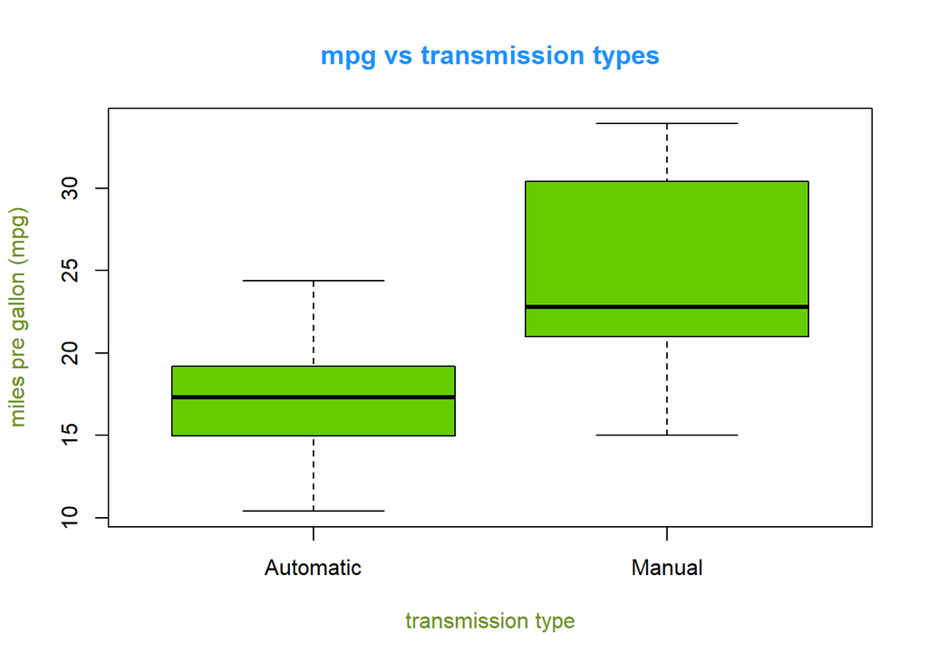

From the boxplot, it seems obvious that cars with manual transmissions have better mpg than those with automatic transmissions (all things being equal).

Let’s perform a statistical analysis using a t-test to confirm (or perhaps reject) this observation. In the t-test below, the null hypothesis is that there is no difference in the mpg output between an automatic transmission and a manual transmission (all things being the same).

```
##
##  Welch Two Sample t-test
##
## data:  mtcars$mpg by mtcars$am
## t = -3.7671, df = 18.332, p-value = 0.001374
## alternative hypothesis: true difference in means is not equal to 0
## 95 percent confidence interval:
##  -11.280194  -3.209684
## sample estimates:
## mean in group Automatic    mean in group Manual
##                17.14737                24.39231
```

The P-value is 0.001374, which is much smaller than our error tollerance level of $\alpha = 0.05.$ So, we reject the null hypothesis. In other words, manual transmission cars have better mpg compared with automatic transmission cars. But this conclusion is based on the assumption that all other variables for both transmission types are the same (for instance, both have the same horse power, the same weight, etc.).

### Multivariable Regression Analysis

```
##
## Call:
## lm(formula = mpg ~ . - 1, data = mtcars)
##
## Residuals:
##     Min      1Q  Median      3Q     Max
## -3.4506 -1.6044 -0.1196  1.2193  4.6271
##
## Coefficients:
##             Estimate Std. Error t value Pr(>|t|)
## cyl         -0.11144    1.04502  -0.107   0.9161
## disp         0.01334    0.01786   0.747   0.4635
## hp          -0.02148    0.02177  -0.987   0.3350
## drat         0.78711    1.63537   0.481   0.6353
## wt          -3.71530    1.89441  -1.961   0.0633 .
## qsec         0.82104    0.73084   1.123   0.2739
## vs           0.31776    2.10451   0.151   0.8814
## amAutomatic 12.30337   18.71788   0.657   0.5181
## amManual    14.82360   18.35265   0.808   0.4283
## gear         0.65541    1.49326   0.439   0.6652
## carb        -0.19942    0.82875  -0.241   0.8122
## ---
## Signif. codes:  0 '***' 0.001 '**' 0.01 '*' 0.05 '.' 0.1 ' ' 1
##
## Residual standard error: 2.65 on 21 degrees of freedom
## Multiple R-squared:  0.9895, Adjusted R-squared:  0.984
## F-statistic: 179.8 on 11 and 21 DF,  p-value: < 2.2e-16
```

The above linear model includes all the 11 variables.

If we focus on only a few variables (for instance: wt, qsec, and am), we get the following linear model:

```
##
## Call:
## lm(formula = mpg ~ wt + qsec + am, data = mtcars)
##
## Residuals:
##     Min      1Q  Median      3Q     Max
## -3.4811 -1.5555 -0.7257  1.4110  4.6610
##
## Coefficients:
##             Estimate Std. Error t value Pr(>|t|)
## (Intercept)   9.6178     6.9596   1.382 0.177915
## wt           -3.9165     0.7112  -5.507 6.95e-06 ***
## qsec          1.2259     0.2887   4.247 0.000216 ***
## amManual      2.9358     1.4109   2.081 0.046716 *
## ---
## Signif. codes:  0 '***' 0.001 '**' 0.01 '*' 0.05 '.' 0.1 ' ' 1
##
## Residual standard error: 2.459 on 28 degrees of freedom
## Multiple R-squared:  0.8497, Adjusted R-squared:  0.8336
## F-statistic: 52.75 on 3 and 28 DF,  p-value: 1.21e-11
```

This model has about 85% of the total variance. If we look further to the correlation of am with mpg ~ wt + qsec, we obtain the following result:

```
##
## Call:
## lm(formula = mpg ~ factor(am):wt + factor(am):qsec, data = mtcars)
##
## Residuals:
##     Min      1Q  Median      3Q     Max
## -3.9361 -1.4017 -0.1551  1.2695  3.8862
##
## Coefficients:
##                          Estimate Std. Error t value Pr(>|t|)
## (Intercept)               13.9692     5.7756   2.419  0.02259 *
## factor(am)Automatic:wt    -3.1759     0.6362  -4.992 3.11e-05 ***
## factor(am)Manual:wt       -6.0992     0.9685  -6.297 9.70e-07 ***
## factor(am)Automatic:qsec   0.8338     0.2602   3.205  0.00346 **
## factor(am)Manual:qsec      1.4464     0.2692   5.373 1.12e-05 ***
## ---
## Signif. codes:  0 '***' 0.001 '**' 0.01 '*' 0.05 '.' 0.1 ' ' 1
##
## Residual standard error: 2.097 on 27 degrees of freedom
## Multiple R-squared:  0.8946, Adjusted R-squared:  0.879
## F-statistic: 57.28 on 4 and 27 DF,  p-value: 8.424e-13
```

## Appendix

### Appendix 1. Pair Panel

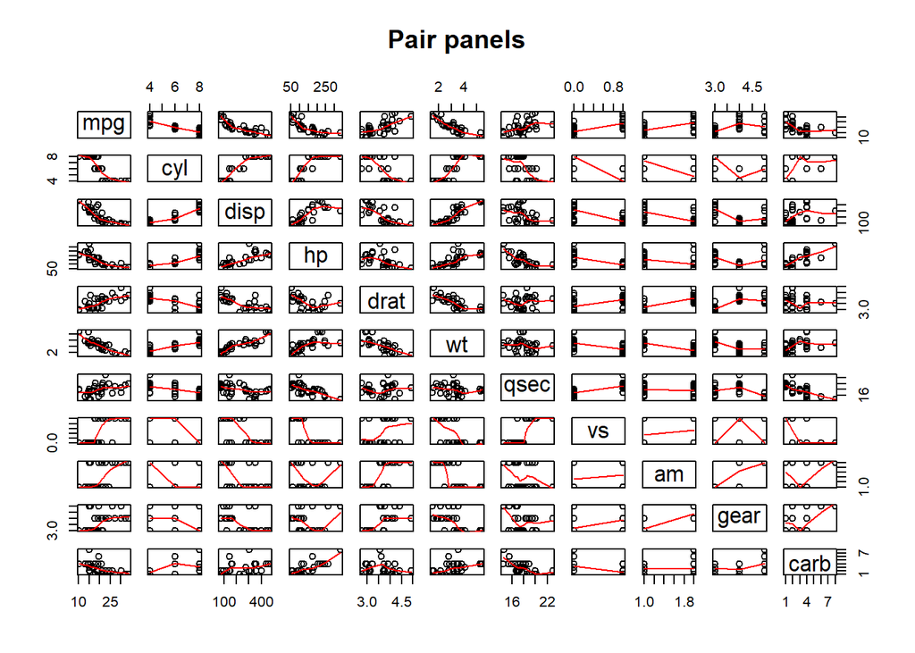

### Appendix 2. Density plot

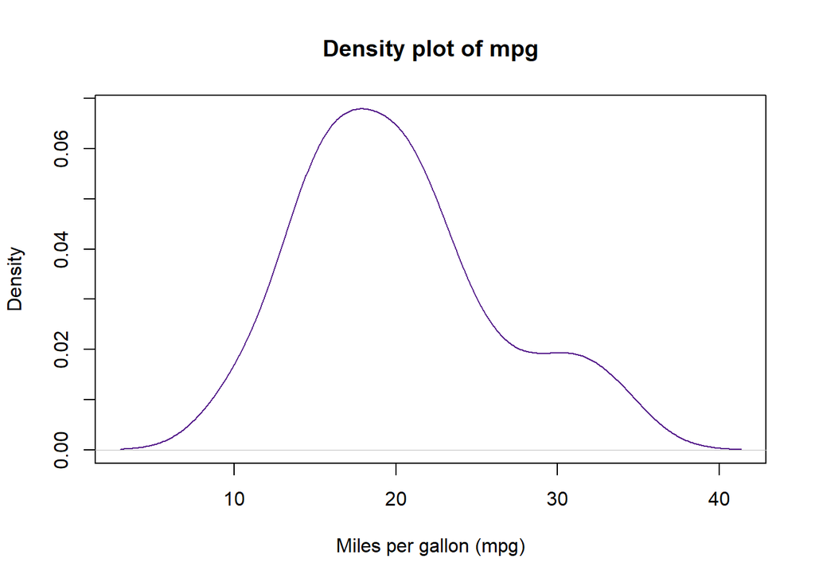

### Appendix 3. Final model residuals

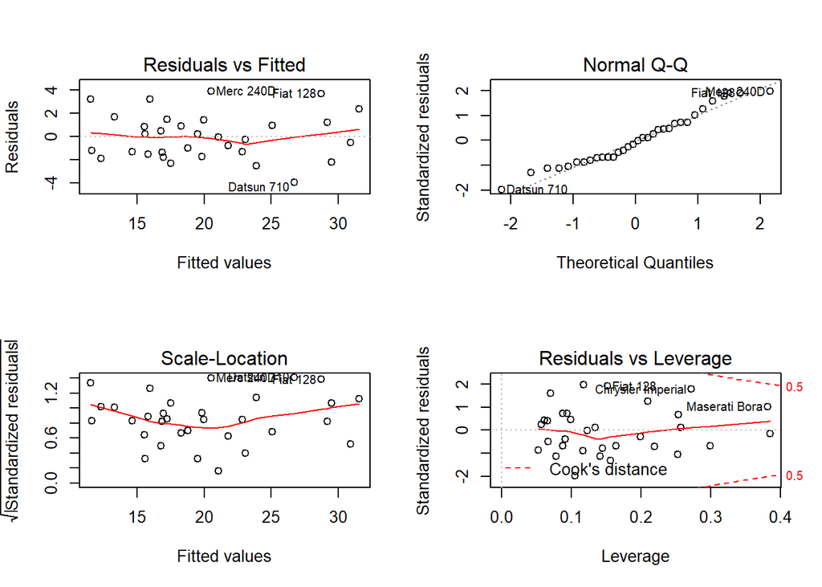

### Appendix 4. Fitting a logistic regression model to the transmission data

```
              Estimate Std. Error   z value    Pr(>|z|)
(Intercept) -6.6035267  2.3514416 -2.808289 0.004980557
mpg          0.3070282  0.1148416  2.673493 0.007506579
```

```
(Intercept)         mpg
0.001355579 1.359379288
```

```
(Intercept)
  -6.603527
```

```
      mpg
0.3070282
```

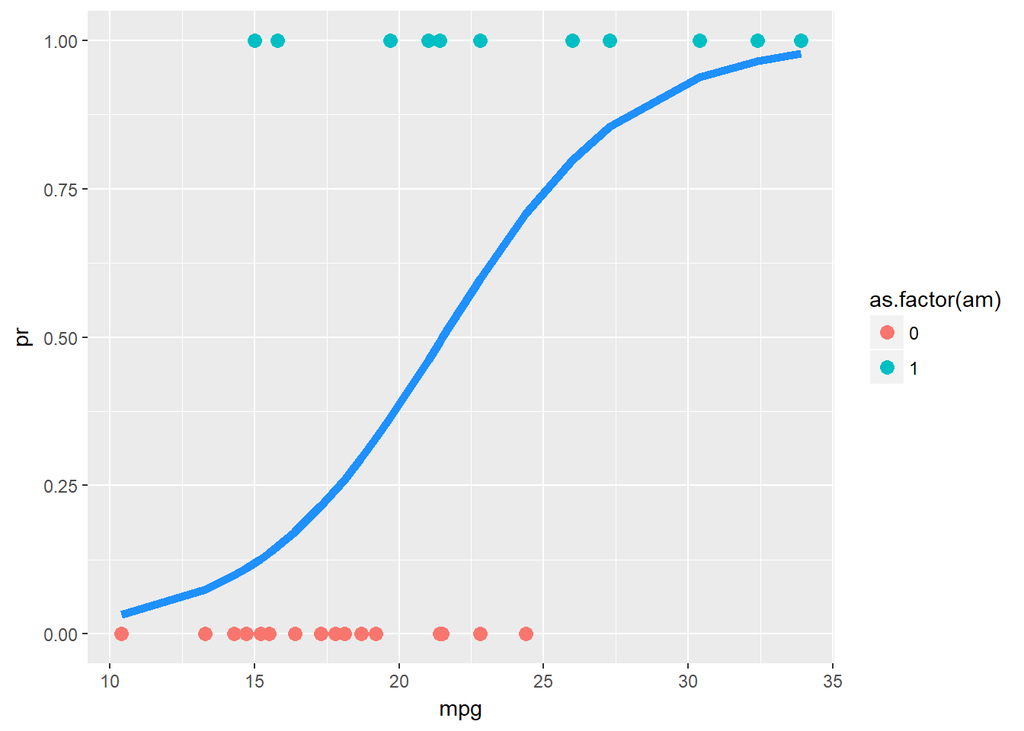